# Categorical class 9

# 1 Packages

```r
library(Stat2Data)  # data
library(dplyr)      # data manipulation
library(ggplot2)    # plots
theme_set(theme_classic(base_size = 16)) # Set ggplot theme and increase font
library(epitools)   # contingency table calculations
library(DescTools)  # G^2 test statistic
library(ggrepel)    # adding text annotations to plots
```

# 2 Data

- **Stat2Data** package: [Link](https://cran.r-project.org/web/packages/Stat2Data/index.html)
  - `Whickham2` dataset: Mortality data, smoking status, and age for $n = 1314$ women in Whickham, England
    - `Outcome`: Status at 20-year follow-up (`Alive` or `Dead`)
    - `Smoker`: Smoker at baseline? (`No` or `Yes`)
    - `Age`: Age (in years at baseline)
    - `AgeGroup`: Age group (`18-64` or `65+`)
    - `Alive`: Numeric code for Outcome (`1` = alive or `0` = dead)
  - Described here: Appleton, D. R., French, J. M., and Vanderpump, M.P. (1996), Ignoring a Covariate: An Example of Simpson’s Paradox, *The American Statistician, 50*, 340-341.

```r
data(Whickham2)
head(Whickham2, n = 10)
```

```
   Outcome Smoker Age AgeGroup Alive
1    Alive    Yes  23    18-64     1
2    Alive    Yes  18    18-64     1
3     Dead    Yes  71      65+     0
4    Alive     No  67      65+     1
5    Alive     No  64    18-64     1
6    Alive    Yes  38    18-64     1
7    Alive    Yes  45    18-64     1
8     Dead     No  76      65+     0
9    Alive     No  28    18-64     1
10   Alive     No  27    18-64     1
```

## 2.1 `AgeGroup3`: Create a 3 category variable from `Age`

- Create a new variable called `AgeGroup3` based on `Age`
  - `AgeGroup3` = 1 if `Age` is 18 to 40
  - `AgeGroup3` = 2 if `Age` is 41 to 64
  - `AgeGroup3` = 3 if `Age` otherwise (i.e., 65+)

```r
Whickham2 <- Whickham2 %>%
    mutate(AgeGroup3 = ifelse(Age %in% 18:40, 1,
           ifelse(Age %in% 41:64, 2, 3)))
head(Whickham2)
```

```
  Outcome Smoker Age AgeGroup Alive AgeGroup3
1   Alive    Yes  23    18-64     1         1
2   Alive    Yes  18    18-64     1         1
3    Dead    Yes  71      65+     0         3
4   Alive     No  67      65+     1         3
5   Alive     No  64    18-64     1         2
6   Alive    Yes  38    18-64     1         1
```

# 3 More variable categories

- Contingency table of `AgeGroup3` vs `Alive`
  - Row variable then column variable

```r
Age3_Alive <- table(Whickham2$AgeGroup3, Whickham2$Alive)
```

- Add labels for the variable names (dimensions)
  - Same order: Rows then columns

```r
names(dimnames(Age3_Alive)) <- list("AgeGroup", "Alive")
```

- Add labels for the categories
  - Order in the dataset
    - `AgeGroup3` is 1 for “18 to 40”, 2 for “41 to 64”, 3 for “65+”
    - `Alive` is 0 for “Dead”, 1 for “Alive”

```r
rownames(Age3_Alive) <- c("18 to 40", "41 to 64", "65+")
colnames(Age3_Alive) <- c("Dead", "Alive")
```

- Fully labeled joint table

```r
Age3_Alive
```

```
          Alive
AgeGroup   Dead Alive
  18 to 40   19   521
  41 to 64  141   390
  65+       209    34
```

- Add margins to the table

```r
addmargins(Age3_Alive)
```

```
          Alive
AgeGroup   Dead Alive  Sum
  18 to 40   19   521  540
  41 to 64  141   390  531
  65+       209    34  243
  Sum       369   945 1314
```

## 3.1 Partitioned $\chi^2$

- Expected values

```r
addmargins(expected(Age3_Alive))
```

```
          Alive
AgeGroup        Dead    Alive  Sum
  18 to 40 151.64384 388.3562  540
  41 to 64 149.11644 381.8836  531
  65+       68.23973 174.7603  243
  Sum      369.00000 945.0000 1314
```

### 3.1.1 Overall $\chi^2$

- For entire $3 \times 2$ table

```r
Age3_Alive_chi2 <- chisq.test(Age3_Alive, correct = FALSE)
Age3_Alive_chi2
```

```
    Pearson's Chi-squared test

data:  Age3_Alive
X-squared = 565.67, df = 2, p-value < 0.00000000000000022
```

- Test is significant $\rightarrow$ The variables are **not** independent
  - But what’s going on?

### 3.1.2 Partition 1

- 18 to 40 year olds vs 41 to 64 year olds
  - Those are the first two rows of the table, which we select with
    - `Age3_Alive[c(1,2),]`

```r
part1_chi2 <- chisq.test(Age3_Alive[c(1,2),], correct = FALSE)
part1_chi2
```

```
    Pearson's Chi-squared test

data:  Age3_Alive[c(1, 2), ]
X-squared = 111.79, df = 1, p-value < 0.00000000000000022
```

- Test is significant
  - 18 to 40 year olds vs 41 to 64 year olds are different on `Alive` probability

### 3.1.3 Partition 2

- First, create table with original `AgeGroup` variable (18 to 64 vs 65+)
  - Label it all up

```r
Age_Alive <- table(Whickham2$AgeGroup, Whickham2$Alive)
names(dimnames(Age_Alive)) <- list("AgeGroup", "Alive")
rownames(Age_Alive) <- c("18 to 64", "65+")
colnames(Age_Alive) <- c("Dead", "Alive")
```

- (18 to 40 year olds plus 41 to 64 year olds) vs 65+ year olds

```r
part2_chi2 <- chisq.test(Age_Alive, correct = FALSE)
part2_chi2
```

```
    Pearson's Chi-squared test

data:  Age_Alive
X-squared = 495.33, df = 1, p-value < 0.00000000000000022
```

- Test is significant
  - 18 to 64 year olds vs 65+ year olds are different on `Alive` probability

### 3.1.4 Alternative: $G^2$ statistic

- Overall

```r
GTest(Age3_Alive, correct = "none")
```

```
    Log likelihood ratio (G-test) test of independence without correction

data:  Age3_Alive
G = 584.41, X-squared df = 2, p-value < 0.00000000000000022
```

- 18 to 40 year olds vs 41 to 64 year olds

```r
GTest(Age3_Alive[c(1,2),], correct = "none")
```

```
    Log likelihood ratio (G-test) test of independence without correction

data:  Age3_Alive[c(1, 2), ]
G = 124.02, X-squared df = 1, p-value < 0.00000000000000022
```

- (18 to 40 year olds plus 41 to 64 year olds) vs 65+ year olds

```r
GTest(Age_Alive, correct = "none")
```

```
    Log likelihood ratio (G-test) test of independence without correction

data:  Age_Alive
G = 460.39, X-squared df = 1, p-value < 0.00000000000000022
```

- Overall, same pattern of results as $\chi^2$ test
  - 18 to 40 year olds vs 41 to 64 year olds are different on `Alive` probability
  - 18 to 64 year olds vs 65+ year olds are different on `Alive` probability

## 3.2 Residuals

- Overall $\chi^2$ is significant (from above)

```r
Age3_Alive_chi2
```

```
    Pearson's Chi-squared test

data:  Age3_Alive
X-squared = 565.67, df = 2, p-value < 0.00000000000000022
```

- Observed values from $\chi^2$ test (matches above)

```r
Age3_Alive_chi2$observed
```

```
          Alive
AgeGroup   Dead Alive
  18 to 40   19   521
  41 to 64  141   390
  65+       209    34
```

- Expected values from $\chi^2$ test (matches above)

```r
Age3_Alive_chi2$expected
```

```
          Alive
AgeGroup        Dead    Alive
  18 to 40 151.64384 388.3562
  41 to 64 149.11644 381.8836
  65+       68.23973 174.7603
```

- Raw residuals: observed - expected = $n_{ij} - \hat{\mu}_{ij}$
  - Sort of a pattern, but doesn’t fully account for different **marginal values**
    - i.e., There are 540 people who are 18 to 40, but only 243 people who are 65+

```r
resids <- Age3_Alive_chi2$observed - Age3_Alive_chi2$expected
resids
```

```
          Alive
AgeGroup          Dead       Alive
  18 to 40 -132.643836  132.643836
  41 to 64   -8.116438    8.116438
  65+       140.760274 -140.760274
```

- Standardized residuals: $\frac{n_{ij} - \hat{\mu}_{ij}}{\sqrt{\hat{\mu}_{ij}(1-p_{i+})(1-p_{+j})}}$
  - where $\sqrt{\hat{\mu}_{ij}(1-p_{i+})(1-p_{+j})}$ is std error of raw residuals under $H_0$
  - and $p_{i+} = n_{i+}/n$ and $p_{+j} = n_{+j}/n$
  - Account for the marginal values and variance of residuals

```r
Age3_Alive_chi2$stdres
```

```
          Alive
AgeGroup         Dead      Alive
  18 to 40 -16.549454  16.549454
  41 to 64  -1.015316   1.015316
  65+       22.255953 -22.255953
```

- Cut-off are $\pm 2$
  - *18 to 40 year olds* have **fewer dead** (and more alive) than expected under independence
  - *65+ year olds* have **more dead** (and fewer alive) than expected under independence

# 4 More variables

## 4.1 Partial (conditional) tables

- $2 \times 2$ table, **conditional** on another variable

```r
Age_Alive_Smoker <- table(Whickham2$AgeGroup, Whickham2$Alive, Whickham2$Smoker)
names(dimnames(Age_Alive_Smoker)) <- list("AgeGroup", "Alive", "Smoker")
rownames(Age_Alive_Smoker) <- c("18 to 64", "65+")
colnames(Age_Alive_Smoker) <- c("Dead", "Alive")
Age_Alive_Smoker
```

```
, , Smoker = No

          Alive
AgeGroup   Dead Alive
  18 to 64   65   474
  65+       165    28

, , Smoker = Yes

          Alive
AgeGroup   Dead Alive
  18 to 64   95   437
  65+        44     6
```

```r
addmargins(Age_Alive_Smoker)
```

```
, , Smoker = No

          Alive
AgeGroup   Dead Alive  Sum
  18 to 64   65   474  539
  65+       165    28  193
  Sum       230   502  732

, , Smoker = Yes

          Alive
AgeGroup   Dead Alive  Sum
  18 to 64   95   437  532
  65+        44     6   50
  Sum       139   443  582

, , Smoker = Sum

          Alive
AgeGroup   Dead Alive  Sum
  18 to 64  160   911 1071
  65+       209    34  243
  Sum       369   945 1314
```

## 4.2 Marginal tables

### 4.2.1 Marginal table for `AgeGroup` vs `Alive`

```r
Age_Alive
```

```
          Alive
AgeGroup   Dead Alive
  18 to 64  160   911
  65+       209    34
```

```r
addmargins(Age_Alive)
```

```
          Alive
AgeGroup   Dead Alive  Sum
  18 to 64  160   911 1071
  65+       209    34  243
  Sum       369   945 1314
```

### 4.2.2 Marginal table for `Smoker` vs `Alive`

```r
Smoker_Alive <- table(Whickham2$Smoker, Whickham2$Alive)
names(dimnames(Smoker_Alive)) <- list("Smoker", "Alive")
rownames(Smoker_Alive) <- c("No", "Yes")
colnames(Smoker_Alive) <- c("Dead", "Alive")
Smoker_Alive
```

```
      Alive
Smoker Dead Alive
   No   230   502
   Yes  139   443
```

```r
addmargins(Smoker_Alive)
```

```
      Alive
Smoker Dead Alive  Sum
   No   230   502  732
   Yes  139   443  582
   Sum  369   945 1314
```

## 4.3 Probabilities

### 4.3.1 Unconditional on any variable

- All (joint) cells add up to 1

```r
prop.table(Age_Alive_Smoker)
```

```
, , Smoker = No

          Alive
AgeGroup         Dead      Alive
  18 to 64 0.04946728 0.36073059
  65+      0.12557078 0.02130898

, , Smoker = Yes

          Alive
AgeGroup         Dead      Alive
  18 to 64 0.07229833 0.33257230
  65+      0.03348554 0.00456621
```

### 4.3.2 Conditional on variable 1 (`AgeGroup`)

- Within each `AgeGroup` category, probabilities add up to 1
  - e.g., 0.0606 + 0.4425 + 0.0887 + 0.4080 = 1 (within rounding)

```r
prop.table(Age_Alive_Smoker, margin = 1)
```

```
, , Smoker = No

          Alive
AgeGroup         Dead      Alive
  18 to 64 0.06069094 0.44257703
  65+      0.67901235 0.11522634

, , Smoker = Yes

          Alive
AgeGroup         Dead      Alive
  18 to 64 0.08870215 0.40802988
  65+      0.18106996 0.02469136
```

### 4.3.3 Conditional on variable 2 (`Alive`)

- Within each `Alive` category, probabilities add up to 1
  - e.g., 0.5016 + 0.0296 + 0.4624 + 0.0063 = 1 (within rounding)

```r
prop.table(Age_Alive_Smoker, margin = 2)
```

```
, , Smoker = No

          Alive
AgeGroup          Dead       Alive
  18 to 64 0.176151762 0.501587302
  65+      0.447154472 0.029629630

, , Smoker = Yes

          Alive
AgeGroup          Dead       Alive
  18 to 64 0.257452575 0.462433862
  65+      0.119241192 0.006349206
```

### 4.3.4 Conditional on variable 3 (`Smoker`)

- Within each `Smoker` category, probabilities add up to 1
  - e.g., 0.0888 + 0.6475 + 0.2254 + 0.0383 = 1 (within rounding)

```r
prop.table(Age_Alive_Smoker, margin = 3)
```

```
, , Smoker = No

          Alive
AgeGroup         Dead      Alive
  18 to 64 0.08879781 0.64754098
  65+      0.22540984 0.03825137

, , Smoker = Yes

          Alive
AgeGroup         Dead      Alive
  18 to 64 0.16323024 0.75085911
  65+      0.07560137 0.01030928
```

### 4.3.5 Another way to calculate frequencies and probabilties

- This way is good for making plots
  - It’s kind of a pain to get the values out of a table
  - And they don’t play nice with e.g., **ggplot2**

#### 4.3.5.1 `Alive` vs `AgeGroup`, conditional on `Smoker`

- Line by line description:
  - Calculate the number of rows in the dataset (`n`)
  - Create a new dataset called `Whickham2_freq1`
    - Give it the `Whickham2` dataset
  - Group the data by all three variables so all calculations will be within each combination of variables
    - i.e., a new variable will be within a cell, not for the whole sample
    - Order doesn’t really matter, but I like `Alive` last ($Y$)
  - `summarize()` reduces the dataset to fewer rows
    - And calculates a summary statistic, such as the count of the rows
    - This counts the number of 0s and 1s for each combination of `AgeGroup` and `Smoker`
  - `ungroup()` stops the grouping so we can calculate for the whole dataset again
  - Group the data by the two “predictors” (not `Alive`) so all calculations will be within each combination of those two variables
  - `mutate()` creates new variables
    - `prop` is the number of 0s and 1s divided by the total `n` for that cell
    - `totaln` is the total number of observations in that cell
  - `filter(Alive ==1)` removes the `Alive` = 0 rows, leaving only the `Alive` = 1 rows
    - If you didn’t do this, you’d have 2 rows for each cell of the table
    - Number of 0s, number of 1s

```r
n <- nrow(Whickham2)
Whickham2_freq1 <- Whickham2 %>%
    group_by(AgeGroup, Smoker, Alive) %>%
    summarize(count = n()) %>%
    ungroup() %>%
    group_by(AgeGroup, Smoker) %>%
    mutate(prop = count/sum(count),
           totaln = sum(count)) %>%
    filter(Alive == 1)
head(Whickham2_freq1)
```

```
# A tibble: 4 × 6
# Groups:   AgeGroup, Smoker [4]
  AgeGroup Smoker Alive count  prop totaln
  <fct>    <fct>  <int> <int> <dbl>  <int>
1 18-64    No         1   474 0.879    539
2 18-64    Yes        1   437 0.821    532
3 65+      No         1    28 0.145    193
4 65+      Yes        1     6 0.12      50
```

#### 4.3.5.2 `Alive` vs `Smoker`, conditional on `AgeGroup`

- This is redundent with the previous one, just organized differently
  - But sometimes you want to have all the combinations at hand

```r
n <- nrow(Whickham2)
Whickham2_freq2 <- Whickham2 %>%
    group_by(Smoker, AgeGroup, Alive) %>%
    summarize(count = n()) %>%
    ungroup() %>%
    group_by(Smoker, AgeGroup) %>%
    mutate(prop = count/sum(count),
           totaln = sum(count)) %>%
    filter(Alive == 1)
head(Whickham2_freq2)
```

```
# A tibble: 4 × 6
# Groups:   Smoker, AgeGroup [4]
  Smoker AgeGroup Alive count  prop totaln
  <fct>  <fct>    <int> <int> <dbl>  <int>
1 No     18-64        1   474 0.879    539
2 No     65+          1    28 0.145    193
3 Yes    18-64        1   437 0.821    532
4 Yes    65+          1     6 0.12      50
```

#### 4.3.5.3 `Alive` vs `AgeGroup`: Ignoring (marginal on) `Smoker`

- Basically the same, but no use of `Smoker` anywhere

```r
Whickham2_freq3 <- Whickham2 %>%
    group_by(AgeGroup, Alive) %>%
    summarize(count = n()) %>%
    ungroup() %>%
    group_by(AgeGroup) %>%
    mutate(prop = count/sum(count),
           totaln = sum(count)) %>%
    filter(Alive == 1)
head(Whickham2_freq3)
```

```
# A tibble: 2 × 5
# Groups:   AgeGroup [2]
  AgeGroup Alive count  prop totaln
  <fct>    <int> <int> <dbl>  <int>
1 18-64        1   911 0.851   1071
2 65+          1    34 0.140    243
```

#### 4.3.5.4 `Alive` vs `Smoker`: Ignoring (marginal on) `AgeGroup`

```r
Whickham2_freq4 <- Whickham2 %>%
    group_by(Smoker, Alive) %>%
    summarize(count = n()) %>%
    ungroup() %>%
    group_by(Smoker) %>%
    mutate(prop = count/sum(count),
           totaln = sum(count)) %>%
    filter(Alive == 1)
head(Whickham2_freq4)
```

```
# A tibble: 2 × 5
# Groups:   Smoker [2]
  Smoker Alive count  prop totaln
  <fct>  <int> <int> <dbl>  <int>
1 No         1   502 0.686    732
2 Yes        1   443 0.761    582
```

## 4.4 Plots

### 4.4.1 **Conditional** effect of `AgeGroup`, conditional on `Smoker`…

- The data are in `Whickham2_freq1`
- The $X$ variable is `AgeGroup`
- The $Y$ variable is `prop`
- `geom_point()` adds points from the dataset and variables specified
- `geom_line()` adds lines from the dataset and variables specified
- `ylim(0, 1)` makes the $Y$ axis go from 0 to 1
- `labs(y = "Proportion alive")` changes the label for the $Y$ axis

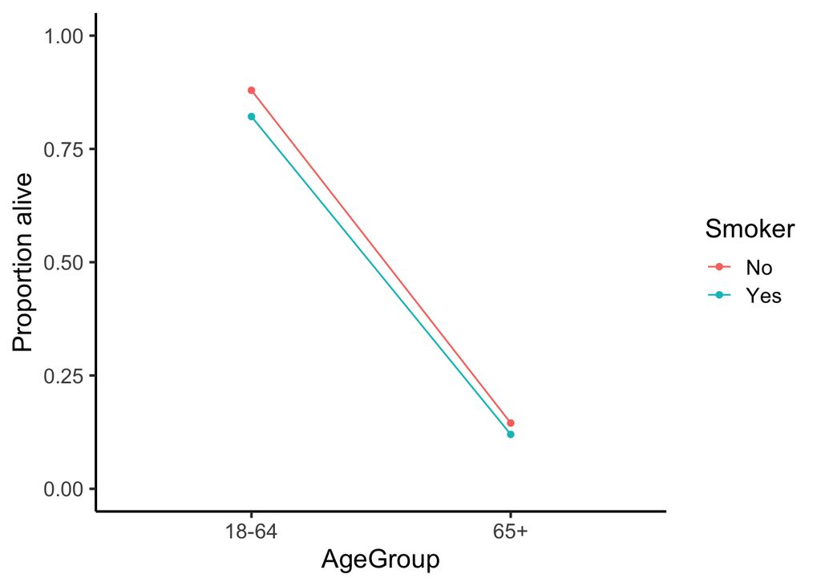

```r
ggplot(data = Whickham2_freq1,
       aes(x = AgeGroup, y = prop)) +
    geom_point(aes(group = Smoker, color = Smoker)) +
    geom_line(aes(group = Smoker, color = Smoker)) +
    ylim(0, 1) +
    labs(y = "Proportion alive")
```

### 4.4.2 …plus **marginal effect**, ignoring `Smoker`

- Only the last two “chunks” are new
  - `geom_point()` adds points
    - From new dataset `Whickham2_freq3`
    - Same $X$ and $Y$ variables
    - `group = 1` is to override the `group = Smoker` above
    - `color = "black"` and `shape = "x"` to change appearance of points
  - `geom_line()` adds a line
    - From new dataset `Whickham2_freq3`
    - Same $X$ and $Y$ variables
    - `group = 1` is to override the `group = Smoker` above
    - `color = "black"` and `linetype = "dashed"` to change appearance of line

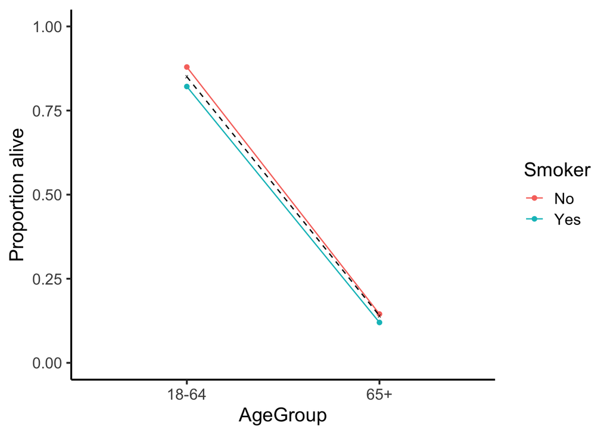

```r
ggplot(data = data.frame(Whickham2_freq1),
       aes(x = AgeGroup, y = prop)) +
    geom_point(aes(group = Smoker, color = Smoker)) +
    geom_line(aes(group = Smoker, color = Smoker)) +
    ylim(0, 1) +
    labs(y = "Proportion alive") +
    geom_point(data = Whickham2_freq3,
               aes(x = AgeGroup, y = prop, group = 1),
               color = "black", shape = "x") +
    geom_line(data = Whickham2_freq3,
              aes(x = AgeGroup, y = prop, group = 1),
              color = "black", linetype = "dashed")
```

### 4.4.3 Add an annotation, such as the total `n` that each point is based on

- `geom_text()` adds text based on variable values
  - `label = totaln` uses the values in `totaln` as the labels
  - `vjust = "outward"` pushes the numbers off the points a bit
    - It doesn’t always look great

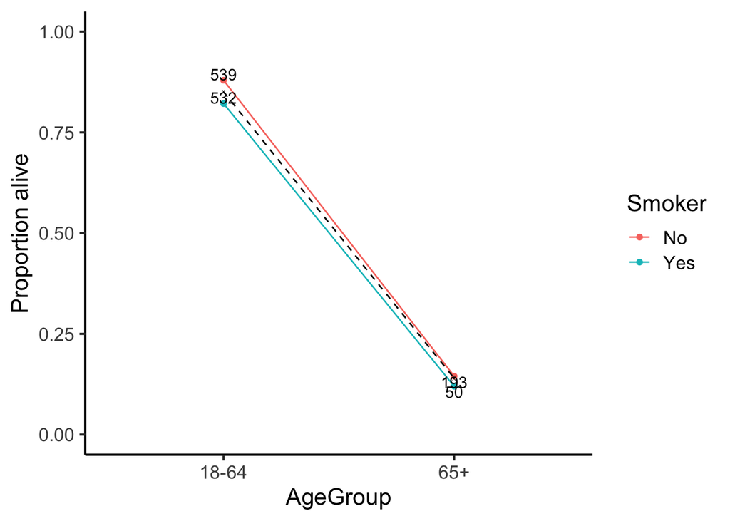

```r
ggplot(data = data.frame(Whickham2_freq1),
       aes(x = AgeGroup, y = prop)) +
    geom_point(aes(group = Smoker, color = Smoker)) +
    geom_line(aes(group = Smoker, color = Smoker)) +
    ylim(0, 1) +
    labs(y = "Proportion alive") +
    geom_point(data = Whickham2_freq3,
               aes(x = AgeGroup, y = prop, group = 1),
               color = "black", shape = "x") +
    geom_line(data = Whickham2_freq3,
              aes(x = AgeGroup, y = prop, group = 1),
              color = "black", linetype = "dashed") +
    geom_text(aes(label = totaln), vjust = "outward")
```

### 4.4.4 Annotation option: Use **ggrepel** package and `geom_text_repel()`

- This often does a better job at pushing labels off points without additional adjustments
  - Also has a ton of other options

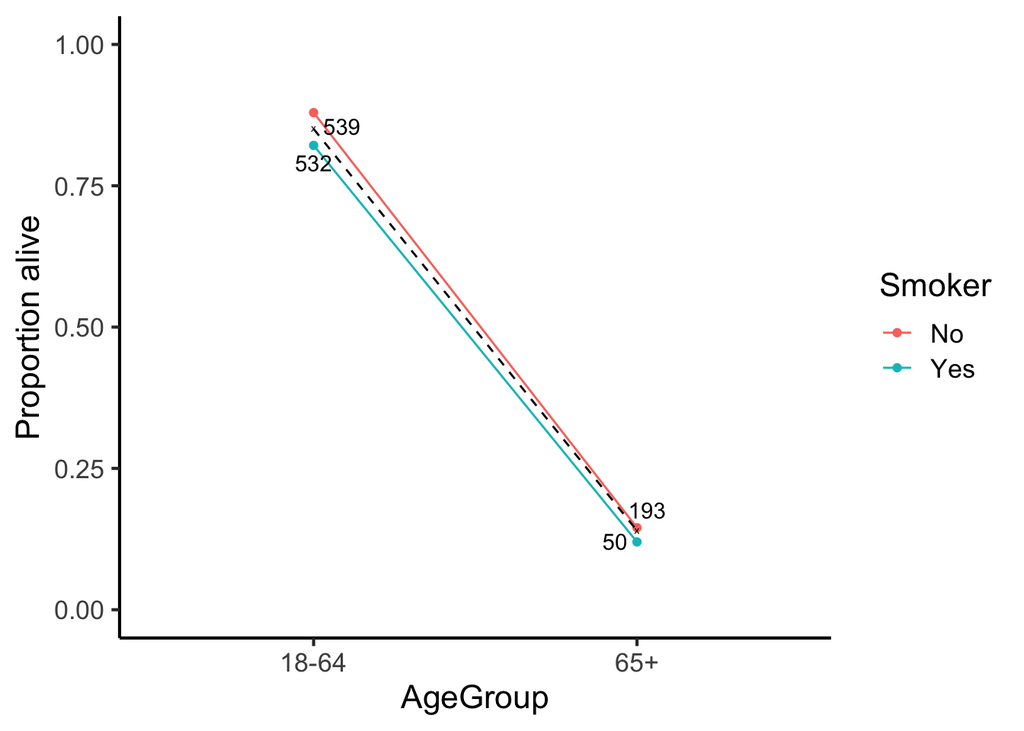

```r
ggplot(data = data.frame(Whickham2_freq1),
       aes(x = AgeGroup, y = prop)) +
    geom_point(aes(group = Smoker, color = Smoker)) +
    geom_line(aes(group = Smoker, color = Smoker)) +
    ylim(0, 1) +
    labs(y = "Proportion alive") +
    geom_point(data = Whickham2_freq3,
               aes(x = AgeGroup, y = prop, group = 1),
               color = "black", shape = "x") +
    geom_line(data = Whickham2_freq3,
              aes(x = AgeGroup, y = prop, group = 1),
              color = "black", linetype = "dashed") +
    geom_text_repel(aes(label = totaln), vjust = "outward")
```